# STAT 331 Project

- Show All Code
- Hide All Code
- View Source

Author

Emily Stokes, Sophia Nicotera, Ben Cox, Wendy Tan

## Project Proposal

For our project, we plan to explore the statistical relationship between education and income across countries. Recent trends in the United States suggest a growing negative attitude toward education, with 49% of Americans believing that a college degree is less important now than in the past (Pew Research). On the contrary to this belief, our hypothesized relationship is that a higher percentage in a bachelor’s degree in a country will lead to higher daily income, as the citizens are more informed and equipped with field-related knowledge. To investigate this, we selected two datasets from GapMinder: (1) Mean daily household income in 2017 constant international PPP dollars, which adjusts for inflation as well as the differences between currencies of different countries (Note: GapMinder includes a “forecast” in this dataset with predicted values up to the year 2100) and (2) Percentage of the population with bachelor’s equivalent attainment

```r
library(readr)
library(tidyverse)
library(kableExtra)
library(gganimate)
library(gifski)
library(patchwork)
library(broom)
```

Data Preparation:

```r
daily_income <- read_csv("mincpcap_cppp.csv")
ba_equiv <- read_csv("se_ter_cuat_ba_zs.csv")
```

Next we needed to combine all information into one dataset to analyze the variables together. Each dataset has a Country/Year pair for each observation of the response, so we can combine the datasets into one large dataset that shows both the income and bachelor’s attainment information for each of the Country/Year’s. Since the last year where real data was recorded was 2023, we will not include years where any value (daily income) is “forecasted” (2024 to 2100). There is only data recorded for bachelor’s attainment beginning in 1970, so we will on only focus our analysis on the years 1970 to 2023, where real data was observed for both of the variables. However, there are 9,636 rows where in a specific Country and Year, either the income, bachelor’s attainment, or both are missing. Since we can’t use these observations, we removed them.

```r
# create a long version for each dataset
di_long <- daily_income |>
  pivot_longer(cols = "1800":"2100",
               names_to = "Year",
               values_to = "DailyIncome")
ba_long <- ba_equiv |>
  pivot_longer(cols = "1970":"2023",
               names_to = "Year",
               values_to = "Bachelors_pct")

# merge all the data from the 2 datasets, but only keep information
# from years where real data was recorded for both variables (only
# from 1970 to 2023)
gapminder <- di_long |>
  full_join(ba_long,
            by = c("country", "Year")) |>
  mutate(Year = as.numeric(Year)) |>
  filter(Year < 2024 & Year >=1970) |>
  drop_na(Bachelors_pct, DailyIncome)
```

## Data Visualization

A scatterplot of each data point in the dataset (each Country + Year) with a best fit line shows a positive relationship between the percentage of the population who have completed a Bachelor’s equivalent education and the average daily household income. However, the correlation does not appear to be super strong because there is a lot of variation in the points.

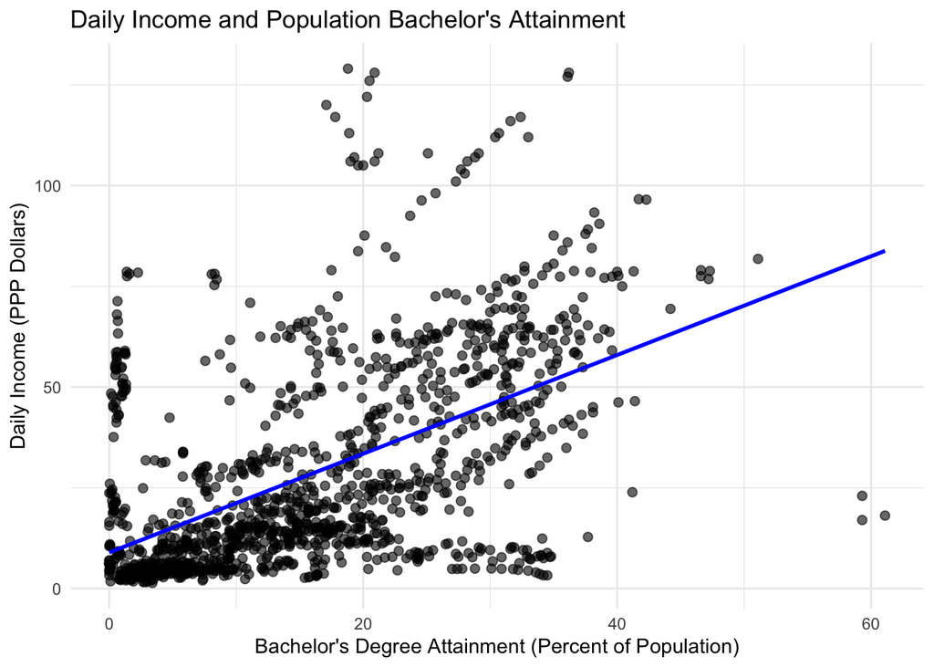

```r
x_min <- min(gapminder$Bachelors_pct, na.rm = TRUE)
x_max <- max(gapminder$Bachelors_pct, na.rm = TRUE)
y_min <- min(gapminder$DailyIncome, na.rm = TRUE)
y_max <- max(gapminder$DailyIncome, na.rm = TRUE)

BA_plot <- gapminder |>
  ggplot(mapping = aes(x = Bachelors_pct, y = DailyIncome)) +
  geom_point(alpha = 0.6, size = 2) +
  geom_smooth(method = "lm", color = "blue", se = FALSE) +
  scale_x_continuous(limits = c(x_min, x_max)) +
  scale_y_continuous(limits = c(y_min, y_max)) +
  labs(x = "Bachelor's Degree Attainment (Percent of Population)",
       y = "Daily Income (PPP Dollars)",
       title = "Daily Income and Population Bachelor's Attainment") +
  theme_minimal()

BA_plot
```

When we look at the relationship between the population percentage with Bachelor’s equivalent attainment (explanatory variable) and daily household income (response variable), we notice that there is not a lot of data before the year 2000, but after the year 2000 there are enough data to form an obvious pattern. From 2000-2008, there are still only a small amount of data points. They form, linear patterns but there is a lot of variation and from year to year the rate of change switched from positive to negative and back. This is most likely explained by the fact that there are not enough data points to see a real pattern. Around 2010 and on, there are many points, and the pattern is still linear with smaller deviation from the regression line, but the rate of change between the two variables is constantly positive even though it varies with each year. However, from 2013 on, the rate of change is the most stable, and the line only varies by a small amount each time. We can conclude that over the years since 2000, the relationship between population bachelor’s attainment and daily household income has been positive.

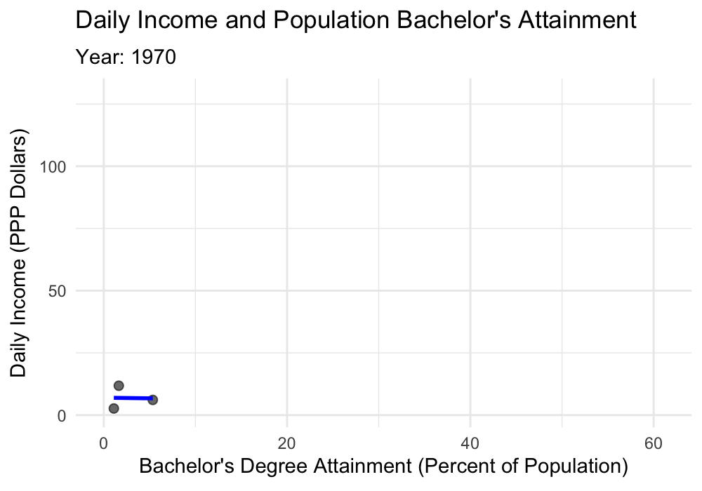

```r
animate_plot <- BA_plot +
  transition_time(Year) +
  ease_aes("linear") +
  labs(subtitle = "Year: {round(frame_time)}")

animated_plot <- animate(animate_plot, renderer = gifski_renderer(), fps = 7, width = 1000, height = 700, units = "px")

anim_save("animation.gif", animated_plot)

animated_plot
```

## Linear Regression

$$\hat{Income} = 1.9434 + 1.4878(Bachelor's \ Attainment \ \%)$$

Where $\hat{Y}$ represents the predicted average income for a country, $\hat{\beta_0} = 1.9434$ is the y-intercept for average daily income for a country, and $\beta_1 = 1.4878$ represents the average change in mean daily household income (in PPP dollars- which are adjusted for inflation) for a country for every 1% increase in the average of the country’s population percentage with a bachelor’s equivalent attainment.

```r
country_averages <- gapminder |>
  group_by(country) |>
  summarise(bachelors = mean(Bachelors_pct, na.rm = TRUE),
            income = mean(DailyIncome, na.rm = TRUE))

bachelors_lm <- lm(income ~ bachelors,
                 data = country_averages)

broom::tidy(bachelors_lm)|>
  dplyr::mutate(across(where(is.numeric), ~ round(.x, 4)))  |>
  knitr::kable(caption = "Model Fit Table for Bachelor's Attainment and Income")|>
    kable_classic(full_width = F, html_font = "Cambria")|>
    row_spec(0, bold = T, color = "black")|>
    add_header_above(c(" " = 5))
```

Model Fit Table for Bachelor's Attainment and Income

| term | estimate | std.error | statistic | p.value |
| --- | --- | --- | --- | --- |
| (Intercept) | 1.9434 | 2.0782 | 0.9351 | 0.351 |
| bachelors | 1.4878 | 0.1265 | 11.7599 | 0.000 |

## Model Fit

To assess model fit, we calculate the variance in total response values, fitted values, and residuals.

```r
bachelor_resid = broom::augment(bachelors_lm, conf.level = 0.95)

bachelor_resid |>
  summarize(sst = var(income),
            ssm = var(.fitted),
            sse = var(.resid)) |>
  mutate(rsqr = ssm/sst) |>
  kable(col.names = c("Total Variance", "Fitted Variance",
                      "Residual Variance", "R^2"),
        caption = "Variance and R^2 for Bachelor's Attainment and Income Model") |>
    kable_classic(full_width = F, html_font = "Cambria") |>
  row_spec(0, bold = T, color = "black") |>
  add_header_above(c(" " = 4))
```

Variance and R^2 for Bachelor's Attainment and Income Model

| Total Variance | Fitted Variance | Residual Variance | R^2 |
| --- | --- | --- | --- |
| 498.0247 | 217.0673 | 280.9575 | 0.4358564 |

## Simulation

In order to gain more information about our linear relationship between Bachelor’s degree attainment and income, we can run a simulation based on our model. We first should make a dataset of predicted values based on our linear regression model.

```r
set.seed(151)

prediction = predict(bachelors_lm)
est_sigma = sigma(bachelors_lm)

rand_error = function(x, mean = 0, sd){
  x + rnorm(length(x), mean, sd)
}

bach_sim_resp = tibble(sim_income = rand_error(x = prediction,
                                               sd = est_sigma))

full_bachelors = country_averages |>
  bind_cols(bach_sim_resp)
```

Now that we have predicted values, we can create a plot to visualize how accurate our values are relative to our original data.

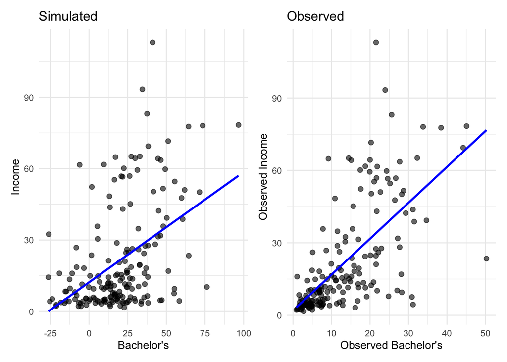

```r
sim_plot <-full_bachelors |>
  ggplot(mapping = aes(x = sim_income, y = income))+
  geom_point(alpha = 0.6, size = 2)+
  geom_smooth(method = "lm", color = "blue", se = FALSE)+
  labs(x = "Bachelor's",
       y = "Income",
       title = "Simulated")+
  theme_minimal()

original_plot <- country_averages |>
  ggplot(mapping = aes(x = bachelors, y = income))+
  geom_point(alpha = 0.6, size = 2)+
  geom_smooth(method = "lm", color = "blue", se = FALSE)+
  labs(x = "Observed Bachelor's",
       y = "Observed Income",
       title = "Observed")+
  theme_minimal()

sim_plot + original_plot
```

$R^2$ provides us with a reliable way to check how much variability in predicted income is explained by the linear relationship between Bachelors’ degree attainment and observed income. We can create a histogram to represent the variability and spread of $R^2$ values in our simulated data.

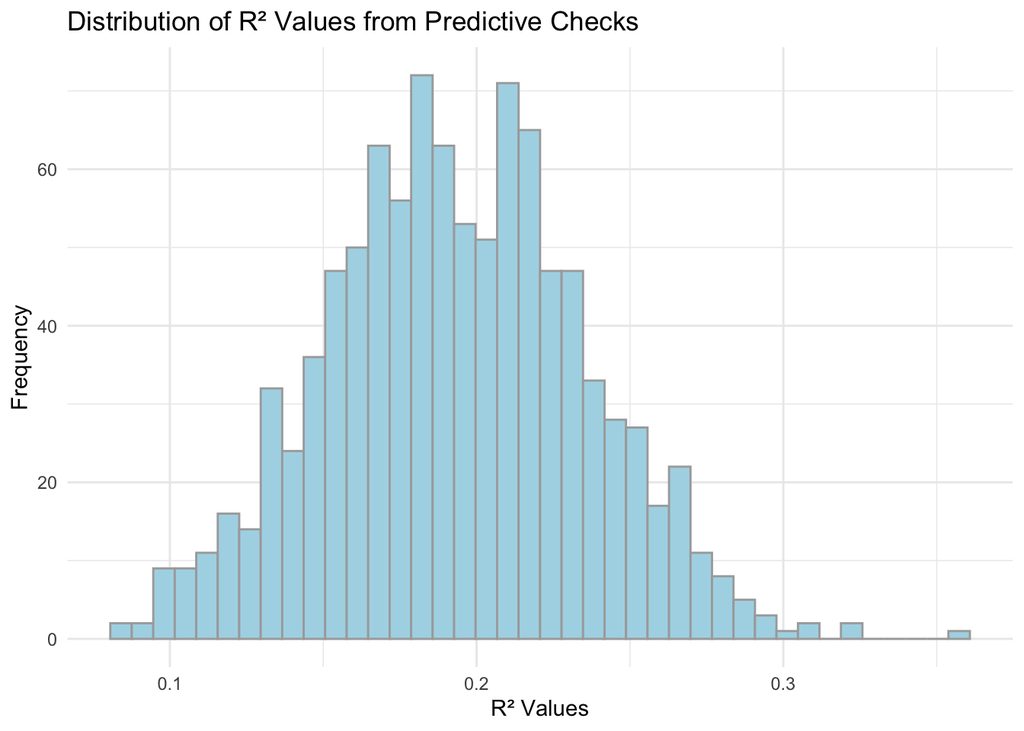

```r
set.seed(256)
sims = map_dfc(.x = 1:1000,
               .f = ~ tibble(sim = rand_error(x = prediction,
                                               sd = est_sigma)))

colnames(sims) <- colnames(sims) |>
  str_replace(pattern = "\\.\\.\\.",
                  replace = "_")

sims = country_averages |>
  select(income) |>
  bind_cols(sims)

sim_r_sq = sims |>
  map(~ lm(income ~ .x, data = sims)) |>
  map(glance) |>
  map_dbl(~ .x$r.squared)

sim_r_sq = sim_r_sq[names(sim_r_sq) != "income"]

tibble(sims = sim_r_sq) |>
  ggplot(aes(x = sims)) +
  geom_histogram(fill = "lightblue",
                 color = "darkgray",
                 bins = 40) +
  labs(x = "R² Values", y = "Frequency",
       title = "Distribution of R² Values from Predictive Checks") +
  theme_minimal()
```

```r
mean(sim_r_sq)
```

```
[1] 0.1932711
```

There seems to be an approximately normal distribution in $R^2$ values in our predicted income, with a values ranging from 0.085 to 0.358. The average $R^2$ is 0.193 with a standard deviation of 0.042.

Sources cited:

Pew Research: Source: https://www.pewresearch.org/social-trends/2024/05/23/public-views-on-the-value-of-a-college-degree/#:~:text=The%20importance%20of%20a%20four%2Dyear%20college%20degree,-Four%2Din%2Dten&text=About%20half%20of%20Americans%20(49,importance%20hasn’t%20really%20changed.